# Stocks Prices

2023-05-26

# Data Used

The data used is the Big Tech Stock Price data. and it is from Yahoo Finance through Kaggle. It includes the daily stock prices and volume of 14 different tech companies. To find out ore on the dataset, check here: https://www.kaggle.com/datasets/evangower/big-techstock-prices.

This data was also one of the datasets used in my class Data visualization coursework.

# Installing libraries

```r
library(tidyverse)
```

# Time range

```r
start = as.Date("04/01/2010")
end = as.Date("29/12/2022")
```

```r
stock_prices <- read.csv("big_tech_stock_prices.csv")
```

```r
# Taking a peek into the dataset.
glimpse(stock_prices)
```

```
## Rows: 45,088
## Columns: 9
## $ X            <int> 1, 2, 3, 4, 5, 6, 7, 8, 9, 10, 11, 12, 13, 14, 15, 16, 17…
## $ stock_symbol <chr> "AAPL", "AAPL", "AAPL", "AAPL", "AAPL", "AAPL", "AAPL", "…
## $ date         <chr> "2010-01-04", "2010-01-05", "2010-01-06", "2010-01-07", "…
## $ open         <dbl> 7.622500, 7.664286, 7.656429, 7.562500, 7.510714, 7.60000…
## $ high         <dbl> 7.660714, 7.699643, 7.686786, 7.571429, 7.571429, 7.60714…
## $ low          <dbl> 7.585000, 7.616071, 7.526786, 7.466071, 7.466429, 7.44464…
## $ close        <dbl> 7.643214, 7.656429, 7.534643, 7.520714, 7.570714, 7.50392…
## $ adj_close    <dbl> 6.515213, 6.526476, 6.422664, 6.410790, 6.453412, 6.39648…
## $ volume       <dbl> 493729600, 601904800, 552160000, 477131200, 447610800, 46…
```

The next step is to create a data frame that captures all rows with just the adjusted price column of each company. The adjusted price is used to account for dividend payments. To do this, I will drop other columns like open, high, close, and low.

Find missing value

```r
sum(is.na(stock_prices))
```

```
## [1] 0
```

The dataset has no missing value.

I want to remove sme columns such as open, close, low, high and volume since I want to do a brief analysis on only the stock price. I am assigning the name, stocks to the new dataset that I am creating.

```r
stocks <- stock_prices %>%
select(-open, -close, -low, -high, -volume)
```

```r
glimpse(stocks)
```

```
## Rows: 45,088
## Columns: 4
## $ X            <int> 1, 2, 3, 4, 5, 6, 7, 8, 9, 10, 11, 12, 13, 14, 15, 16, 17…
## $ stock_symbol <chr> "AAPL", "AAPL", "AAPL", "AAPL", "AAPL", "AAPL", "AAPL", "…
## $ date         <chr> "2010-01-04", "2010-01-05", "2010-01-06", "2010-01-07", "…
## $ adj_close    <dbl> 6.515213, 6.526476, 6.422664, 6.410790, 6.453412, 6.39648…
```

I am creating a new dataset from the existing stocks dataset and extracting information from AAPL, AMZN, CSCO and ADBE from it.

```r
newData <- filter(stocks, stock_symbol %in% c("AAPL", "AMZN", "CSCO", "ADBE"))
```

```r
glimpse(newData)
```

```
## Rows: 13,084
## Columns: 4
## $ X            <int> 1, 2, 3, 4, 5, 6, 7, 8, 9, 10, 11, 12, 13, 14, 15, 16, 17…
## $ stock_symbol <chr> "AAPL", "AAPL", "AAPL", "AAPL", "AAPL", "AAPL", "AAPL", "…
## $ date         <chr> "2010-01-04", "2010-01-05", "2010-01-06", "2010-01-07", "…
## $ adj_close    <dbl> 6.515213, 6.526476, 6.422664, 6.410790, 6.453412, 6.39648…
```

# Create a line plot using stocks dataset.

The geom_line() function adds the line plot to the plot object. The labs() function is used to set the title and axis labels, and theme_minimal() sets a minimalistic theme for the plot.

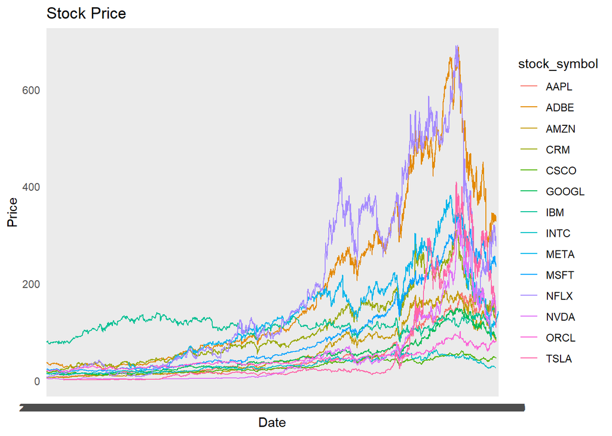

```r
ggplot(stocks, aes(x = date, y = adj_close, group = stock_symbol, color = stock_symbol)) +
  geom_line() +
  labs(title = "Stock Price", x = "Date", y = "Price") +
  theme_minimal()
```

# Create a line plot using newData dataset.

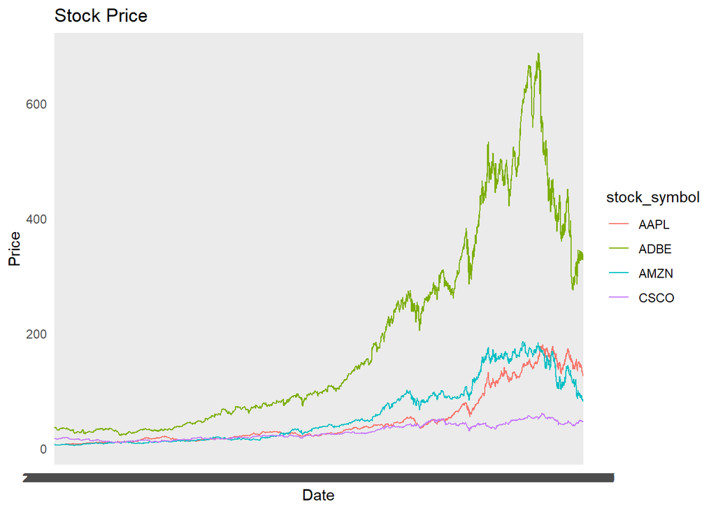

```r
ggplot(newData, aes(x = date, y = adj_close, group = stock_symbol, color = stock_symbol)) +
  geom_line() +
  labs(title = "Stock Price", x = "Date", y = "Price") +
  theme_minimal()
```

Extract Year from date

```r
stocks$date <- as.Date(stocks$date)
```

# extract the year and convert to numeric format

```r
stocks$year <- as.numeric(format(stocks$date, "%Y"))
stocks
```

```
##           X stock_symbol       date  adj_close year
## 1         1         AAPL 2010-01-04   6.515213 2010
## 2         2         AAPL 2010-01-05   6.526476 2010
## 3         3         AAPL 2010-01-06   6.422664 2010
## 4         4         AAPL 2010-01-07   6.410790 2010
## 5         5         AAPL 2010-01-08   6.453412 2010
## 6         6         AAPL 2010-01-11   6.396483 2010
## 7         7         AAPL 2010-01-12   6.323721 2010
## 8         8         AAPL 2010-01-13   6.412922 2010
## 9         9         AAPL 2010-01-14   6.375781 2010
## 10       10         AAPL 2010-01-15   6.269228 2010
## 11       11         AAPL 2010-01-19   6.546568 2010
## 12       12         AAPL 2010-01-20   6.445801 2010
## 13       13         AAPL 2010-01-21   6.334377 2010
## 14       14         AAPL 2010-01-22   6.020202 2010
```

[output cut: 19986 more lines]

```r
glimpse(stocks)
```

```
## Rows: 45,088
## Columns: 5
## $ X            <int> 1, 2, 3, 4, 5, 6, 7, 8, 9, 10, 11, 12, 13, 14, 15, 16, 17…
## $ stock_symbol <chr> "AAPL", "AAPL", "AAPL", "AAPL", "AAPL", "AAPL", "AAPL", "…
## $ date         <date> 2010-01-04, 2010-01-05, 2010-01-06, 2010-01-07, 2010-01-…
## $ adj_close    <dbl> 6.515213, 6.526476, 6.422664, 6.410790, 6.453412, 6.39648…
## $ year         <dbl> 2010, 2010, 2010, 2010, 2010, 2010, 2010, 2010, 2010, 201…
```

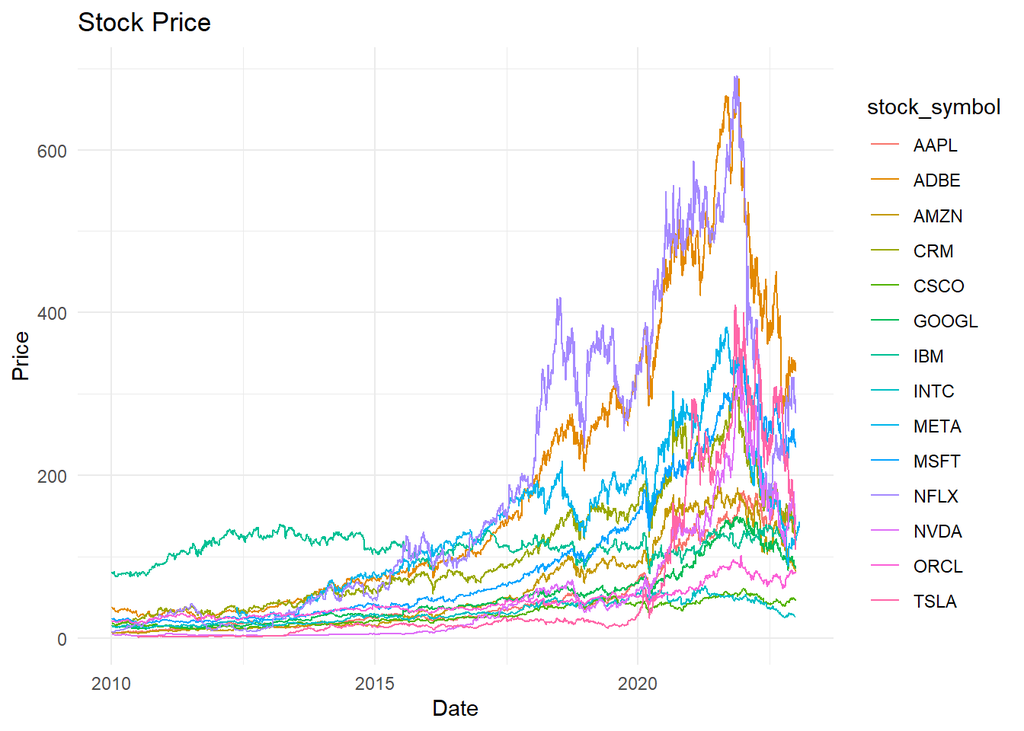

```r
ggplot(stocks, aes(x = date, y = adj_close, group = stock_symbol, color = stock_symbol)) +
  geom_line() +
  labs(title = "Stock Price", x = "Date", y = "Price") +
  theme_minimal()
```

Extract Year from date in newData

```r
newData$date <- as.Date(newData$date)
```

# extract the year and convert to numeric format

```r
newData$year <- as.numeric(format(newData$date, "%Y"))
newData
```

```
##           X stock_symbol       date  adj_close year
## 1         1         AAPL 2010-01-04   6.515213 2010
## 2         2         AAPL 2010-01-05   6.526476 2010
## 3         3         AAPL 2010-01-06   6.422664 2010
## 4         4         AAPL 2010-01-07   6.410790 2010
## 5         5         AAPL 2010-01-08   6.453412 2010
## 6         6         AAPL 2010-01-11   6.396483 2010
## 7         7         AAPL 2010-01-12   6.323721 2010
## 8         8         AAPL 2010-01-13   6.412922 2010
## 9         9         AAPL 2010-01-14   6.375781 2010
## 10       10         AAPL 2010-01-15   6.269228 2010
## 11       11         AAPL 2010-01-19   6.546568 2010
## 12       12         AAPL 2010-01-20   6.445801 2010
## 13       13         AAPL 2010-01-21   6.334377 2010
## 14       14         AAPL 2010-01-22   6.020202 2010
```

[output cut: 13070 more lines]

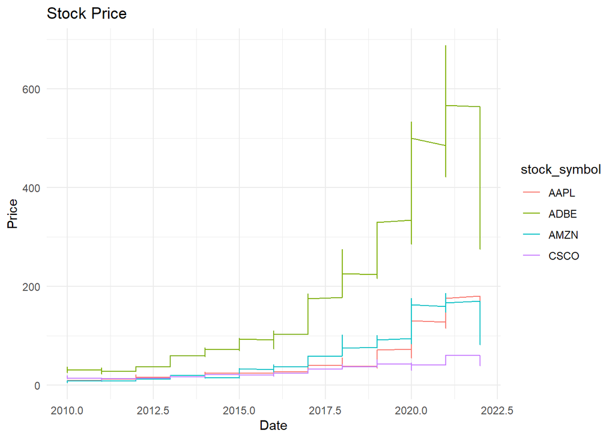

```r
ggplot(newData, aes(x = year, y = adj_close, group = stock_symbol, color = stock_symbol)) +
  geom_line() +
  labs(title = "Stock Price", x = "Date", y = "Price") +
  theme_minimal()
```

```r
newData$year <- as.character(format(newData$date, "%Y"))
newData
```

```
##           X stock_symbol       date  adj_close year
## 1         1         AAPL 2010-01-04   6.515213 2010
## 2         2         AAPL 2010-01-05   6.526476 2010
## 3         3         AAPL 2010-01-06   6.422664 2010
## 4         4         AAPL 2010-01-07   6.410790 2010
## 5         5         AAPL 2010-01-08   6.453412 2010
## 6         6         AAPL 2010-01-11   6.396483 2010
## 7         7         AAPL 2010-01-12   6.323721 2010
## 8         8         AAPL 2010-01-13   6.412922 2010
## 9         9         AAPL 2010-01-14   6.375781 2010
## 10       10         AAPL 2010-01-15   6.269228 2010
## 11       11         AAPL 2010-01-19   6.546568 2010
## 12       12         AAPL 2010-01-20   6.445801 2010
## 13       13         AAPL 2010-01-21   6.334377 2010
## 14       14         AAPL 2010-01-22   6.020202 2010
```

[output cut: 13070 more lines]

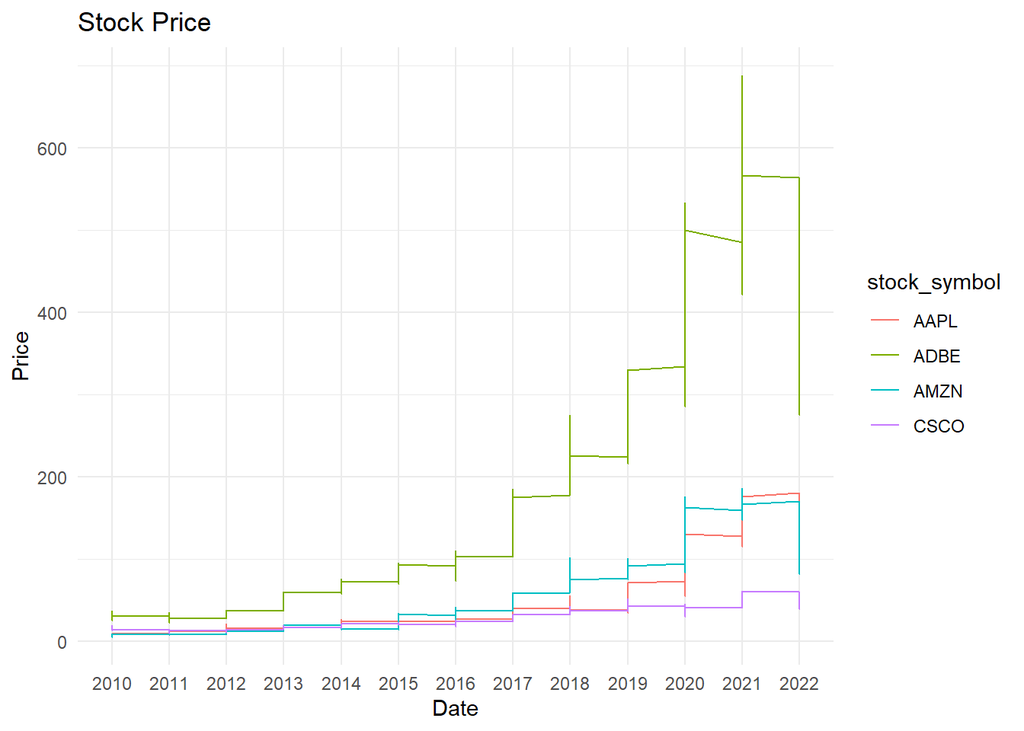

```r
ggplot(newData, aes(x = year, y = adj_close, group = stock_symbol, color = stock_symbol)) +
  geom_line() +
  labs(title = "Stock Price", x = "Date", y = "Price") +
  theme_minimal()
```

I want to flip the date to look clearer, hence I use theme(axis.text.x = element_text(angle=65, vjust=0.6))

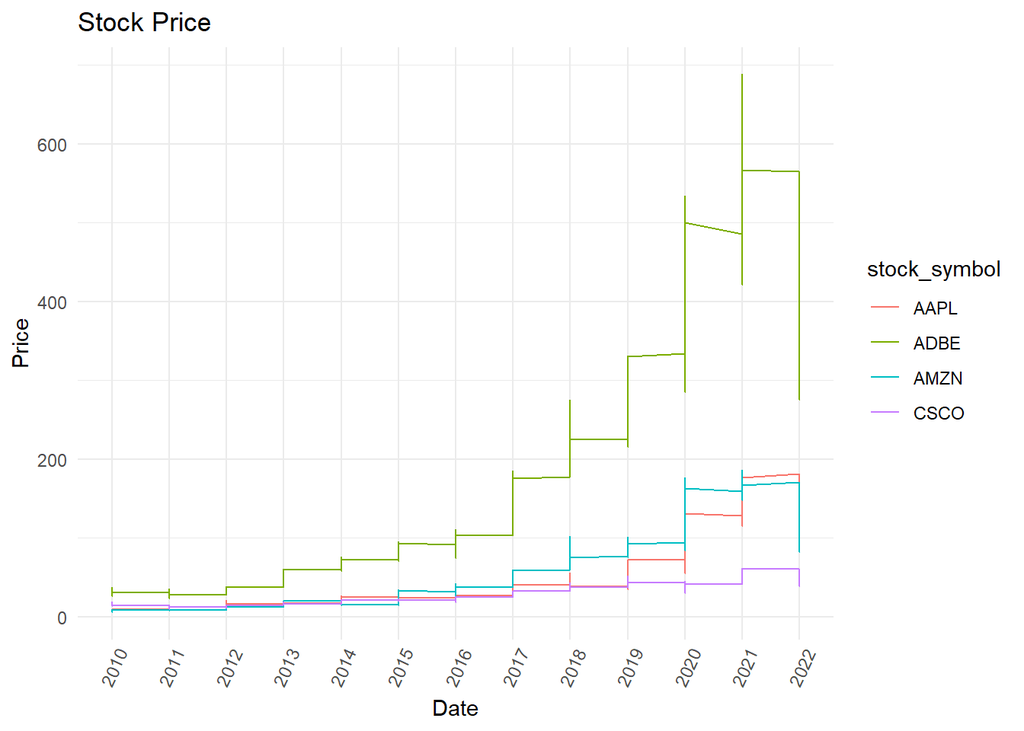

```r
ggplot(newData, aes(x = year, y = adj_close, group = stock_symbol, color = stock_symbol)) +
  geom_line() +
  labs(title = "Stock Price", x = "Date", y = "Price") +
  theme_minimal() +
  theme(axis.text.x = element_text(angle=65, vjust=0.6))
```

Using bar chart to plot the closing price of stocks against year.

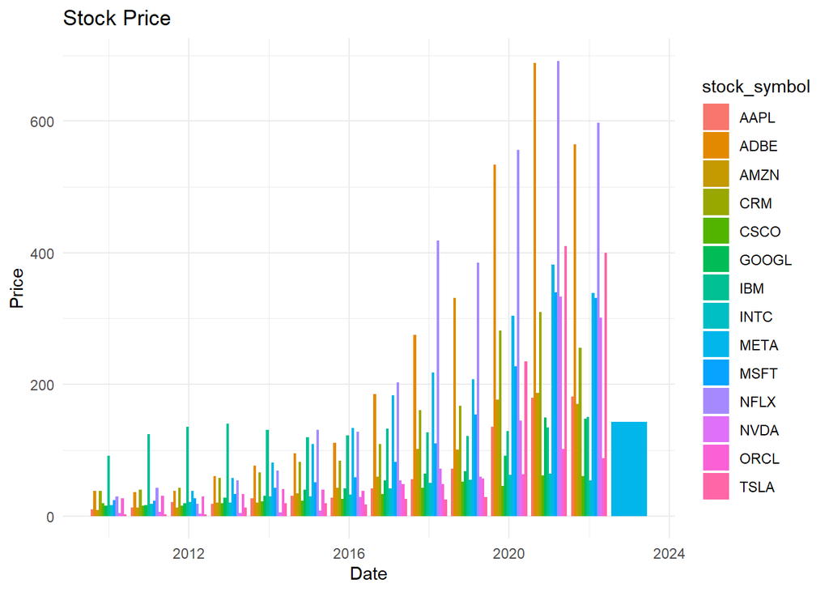

```r
# Create the bar chart
ggplot(stocks, aes(x = year, y = adj_close, fill = stock_symbol)) +
  geom_bar(stat = "identity", position = "dodge") +
  labs(title = "Stock Price", x = "Date", y = "Price") +
  theme_minimal()
```

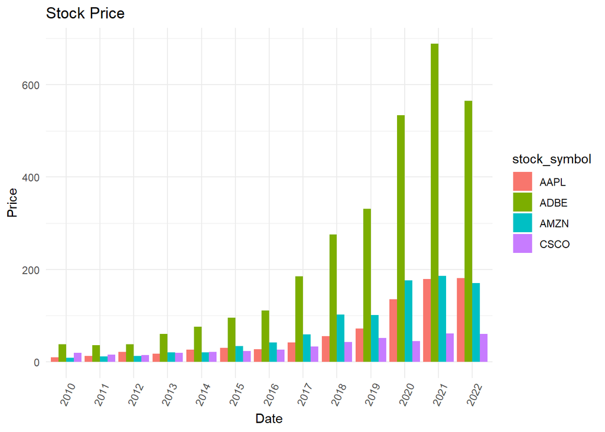

```r
ggplot(newData, aes(x = year, y = adj_close, fill = stock_symbol)) +
  geom_bar(stat = "identity", position = "dodge") +
  labs(title = "Stock Price", x = "Date", y = "Price") +
  theme_minimal() +
  theme(axis.text.x = element_text(angle=65, vjust=0.6))
```

Reference https://medium.com/analytics-vidhya/plot-stock-prices-with-r-6bdbaebc8ec1

https://datascienceplus.com/how-to-get-stock-prices-and-plot-them/

https://www.paradigmses.com/articles/Interactive-Data-Visualization-Using-R-for-Stock-Analysis.html

https://towardsdatascience.com/monitoring-stock-performance-made-easy-with-r-and-shiny-b6ab5fb02085

https://rpubs.com/markloessi/495609

https://jtr13.github.io/cc21fall2/predictive-analytics-using-data-visualization-in-r.html

https://www.r-bloggers.com/2017/04/an-introduction-to-stock-market-data-analysis-with-r-part-2/

https://ntguardian.wordpress.com/2017/03/27/introduction-stock-market-data-r-1/

https://alphaarchitect.com/2020/01/visualization-sector-trends-with-r-code/

https://www.geeksforgeeks.org/ge-stock-price-analysis-using-r-language/

Doing Ml with R https://www.datacamp.com/tutorial/machine-learning-in-r

https://machinelearningmastery.com/machine-learning-in-r-step-by-step/

tweets dataset for python deeplearning https://www.kaggle.com/datasets/kazanova/sentiment140